# hw#4.data624

# f. Compare the RMSE of the ETS model with the RMSE of the models you obtained using STL decompositions. Which gives the better in-sample fits?

For RMSE on entire set, STL model - ANN with no demped gives us the best result (the lowest RMSE).

```r
# STL model - AAN with demped (RMSE on entire set) - 23.32
summary(fcast)
```

```
##
## Forecast method: STL +  ETS(A,Ad,N)
##
## Model Information:
## ETS(A,Ad,N)
##
## Call:
##  ets(y = x, model = etsmodel, damped = TRUE, allow.multiplicative.trend = allow.multiplicative.trend)
##
##   Smoothing parameters:
##     alpha = 0.7037
##     beta  = 1e-04
##     phi   = 0.9243
##
##   Initial states:
##     l = 341.6239
##     b = -5.0799
##
##   sigma:  23.8549
##
##      AIC     AICc      BIC
## 1257.950 1258.743 1274.314
##
## Error measures:
##                    ME     RMSE      MAE        MPE     MAPE     MASE
## Training set 1.551267 23.32113 18.48987 0.07585736 5.955086 0.602576
##                    ACF1
## Training set 0.02262668
##
## Forecasts:
##         Point Forecast    Lo 80    Hi 80    Lo 95    Hi 95
## 2005 Q2       403.1624 372.5912 433.7336 356.4077 449.9171
## 2005 Q3       403.1613 365.7770 440.5457 345.9869 460.3357
```

```r
# STL model - AAN with no demped (RMSE on entire set) - 23.3
summary(fcast_nodamp)
```

```
##
## Forecast method: STL +  ETS(A,A,N)
##
## Model Information:
## ETS(A,A,N)
##
## Call:
##  ets(y = x, model = etsmodel, damped = FALSE, allow.multiplicative.trend = allow.multiplicative.trend)
##
##   Smoothing parameters:
##     alpha = 0.7248
##     beta  = 1e-04
##
##   Initial states:
##     l = 328.1086
##     b = 0.9202
##
##   sigma:  23.7186
##
##      AIC     AICc      BIC
## 1255.697 1256.258 1269.334
##
## Error measures:
##                      ME   RMSE     MAE        MPE     MAPE      MASE
## Training set -0.3412727 23.295 18.1605 -0.5520141 5.884617 0.5918418
##                    ACF1
## Training set 0.02103582
##
## Forecasts:
##         Point Forecast    Lo 80    Hi 80    Lo 95    Hi 95
## 2005 Q2       404.3251 373.9285 434.7216 357.8375 450.8126
## 2005 Q3       405.2414 367.6977 442.7850 347.8233 462.6594
```

```r
# ETS model - ANA (RMSE on entire set) - 25.23
summary(ets_model)
```

```
## ETS(A,N,A)
##
## Call:
##  ets(y = ukcars)
##
##   Smoothing parameters:
##     alpha = 0.6199
##     gamma = 1e-04
##
##   Initial states:
##     l = 314.2568
##     s = -1.7579 -44.9601 21.1956 25.5223
##
##   sigma:  25.9302
##
##      AIC     AICc      BIC
## 1277.752 1278.819 1296.844
##
## Training set error measures:
##                    ME     RMSE      MAE        MPE     MAPE      MASE
## Training set 1.313884 25.23244 20.17907 -0.1570979 6.629003 0.6576259
##                    ACF1
## Training set 0.02573334
```

# g. Compare the forecasts from the three approaches? Which seems most reasonable?

For RMSE on testset, STL with demped is the most reasonable - the lowest RMSE.

```r
# MSE for STL with demped
e <- tsCV(fit_sea, stlf, etsmodel = "AAN", damped=TRUE, h=2)

# RMSE on testset - STL with demped
sqrt(mean(e^2, na.rm=TRUE))
```

```
## [1] 28.37616
```

[output not shown]

```r
# MSE for STL with no demped
e2 <- tsCV(fit_sea, stlf, etsmodel = "AAN", damped=FALSE, h=2)

# RMSE on testset - STL with no demped
sqrt(mean(e2^2, na.rm=TRUE))
```

```
## [1] 29.13164
```

[output not shown]

```r
# MSE for STL with no demped
f  <- function(y, h) {
  forecast(ets(y), h = h)
}

e3 <- tsCV(ukcars, f, h=2)

# RMSE on testset - est with ANA
sqrt(mean(e3^2, na.rm=TRUE))
```

```
## [1] 34.4618
```

[output not shown]

```r
# RMSE on all dataset - For STL with demped
#sqrt(mean(residuals(stlf(fit_sea, etsmodel = "AAN", damped=TRUE, h = 2))^2, na.rm=TRUE))
```

# h. Check the residuals of your preferred model.

since p value < 0.05 and spikes appear in ACF plots, we reject null hypothesis that residuals are uncorrelated (null hypothesis of independence is rejected - the residuals are correlated). From the Normality plot, the plot sugests that residuals are fairly normally distributed (residuals have mean fairly close to zero).

Therefore, we conclude that my preferred model does not forecast correctly.

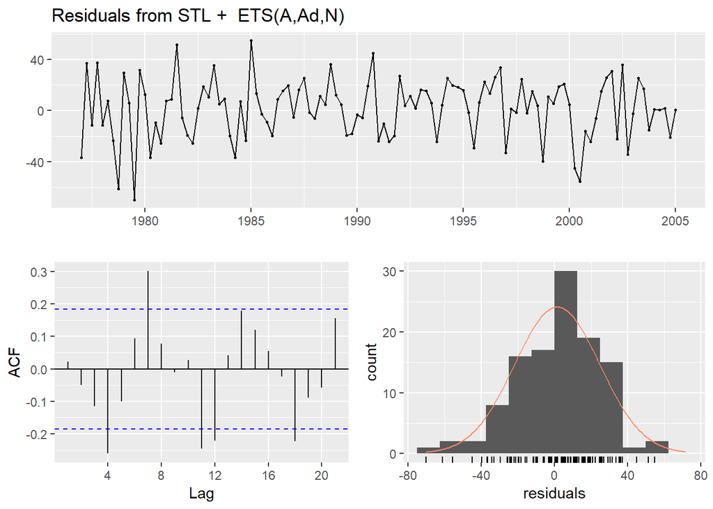

```
##
##  Ljung-Box test
##
## data:  Residuals from STL +  ETS(A,Ad,N)
## Q* = 24.138, df = 3, p-value = 2.337e-05
##
## Model df: 5.   Total lags used: 8
```

```r
checkresiduals(fcast)
```

```r
#checkresiduals(stlf(fit_sea, etsmodel = "AAN", damped=TRUE))
```